# Merging and Analyzing Tribes, Precipitation, EPA Risk

Katie McConnell

2/25/2019

### Download Libraries

```r
library(readr)
library(tidyr)
library(knitr)
library(DT)
library(ggbeeswarm)
library(dplyr)
library(stringr)
library(scales)
library(broom)
library(ggplot2)
```

## Import and Process Data

Tribes data comes from an .RData file that Justin created (documentation available in ’data wrangle change score centroid and map data.R`). Precipitation and EPA data are stored in R_Analysis > _Variables.

```r
# Set working directory
setwd("/Users/kathrynmcconnell/Documents/GitHub/tribal_lands2/R_Analysis/_Variables")

# Download tribes data and select distinct records only
load("/Users/kathrynmcconnell/Documents/GitHub/tribal_lands2/R_Analysis/processed_data.RData")
data_long <- distinct(merged_data_record_all_long, tribe, time, FIPS, .keep_all = TRUE)

# Import EPA climate change and precipitation variables to be joined to tribes data
climate <- read_csv("EPA_CSRI_Index_Final.csv") %>% select(FIPS, FIPS_manual, Risk, CRSI)
precip <- read_csv("MeanAnnualPrecipitation.csv") %>% select(FIPS, MeanAnnualPrecipitation_in)
```

Process data.

```r
# In EPA climate data, for counties that are missing automatic FIPS designations use manual FIPS designation instead
climate[1:126,]$FIPS <- climate[1:126,]$FIPS_manual

# For all three datasets, change FIPS from character to integer to make future joins function
climate$FIPS <- as.numeric(climate$FIPS)
precip$FIPS <- as.numeric(precip$FIPS)
data_long$FIPS <- as.numeric(data_long$FIPS)
```

Join precipitation and EPA climate data to tribes dataframe.

```r
# Join new variables to all tribe records
main_join1 <- left_join(data_long, precip, c("FIPS" = "FIPS")) %>%
  left_join(climate, c("FIPS" = "FIPS")) %>%
  mutate(Precip = MeanAnnualPrecipitation_in) %>%
  select(-(FIPS_manual)) %>%
  select(-(MeanAnnualPrecipitation_in))
```

Create data.frame to include only tribes with time 1 and 2 data.

```r
data_t1and2_long <- filter(main_join1, tribe %in% tribes_time1and2_lst$tribe)

# Change FIPS from character to numeric
data_t1and2_long$FIPS <- as.numeric(data_t1and2_long$FIPS)
```

**Check Data** First, confirm the data is correct, each tribe should have 2 summarized records in total, one for time 1 and one for time 2, so the resulted data.frame should has 0 row.

```r
t1and2_lst <- group_by(data_t1and2_long, tribe, time) %>%
  count() %>%
  ungroup() %>%
  group_by(tribe) %>%
  count() %>%
  filter(nn < 2)

nrow(t1and2_lst)
```

```
## [1] 0
```

## Exploratory Analyses

### Plot Precipitation and EPA Risk Variable

### All Tribes, including those with time 1 or time 2 data only

- Because the total number of counties with tribes present was reduced so much between t1 and t2, it’s difficult to get a sense of exactly how the precipitation distributions differ. However it does seem that the t2 distribution may skew more towards lower precipitation.
- EPA’s risk score seems to be more evenly distributed across counties with tribes present at t2 than at t1 (where it is skewed toward lower risk). Of note, in the box plot there is a cluster of counties at t2 around risk = .65 that are likely also geographically clustered, and would be interesting to look into.

**Precipitation for all tribes**

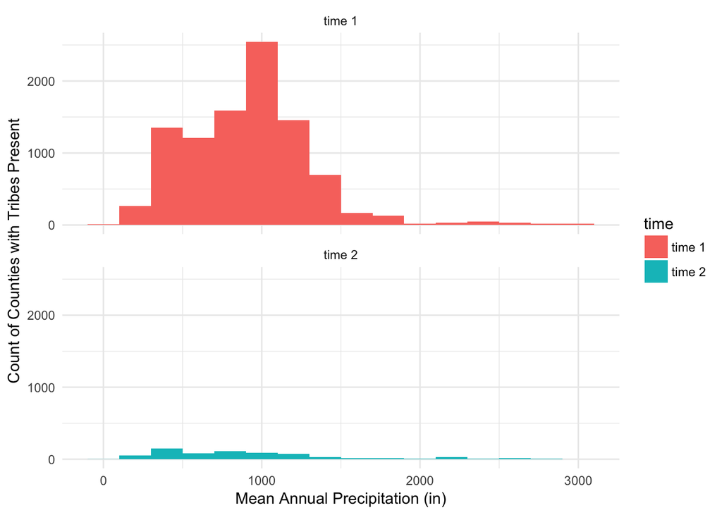

```r
ggplot(main_join1, aes(Precip, fill = time)) +
  geom_histogram(position = "dodge", binwidth = 200) +
  theme_minimal() +
  ylab("Count of Counties with Tribes Present") +
  xlab("Mean Annual Precipitation (in)") +
  facet_wrap(~ time, nrow = 2)
```

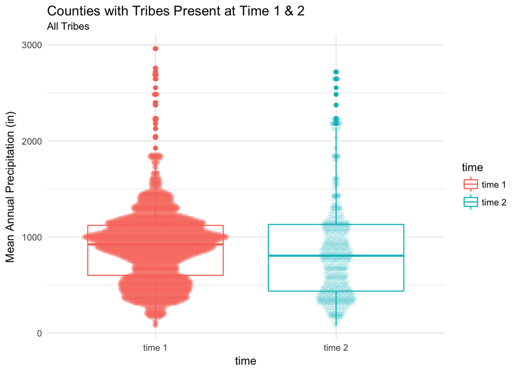

```r
ggplot(main_join1, aes(time, Precip, colour = time)) +
  geom_boxplot() +
  geom_quasirandom(alpha = 1/10, varwidth = TRUE) +
  theme_minimal() +
  ylab("Mean Annual Precipitation (in)") +
  ggtitle("Counties with Tribes Present at Time 1 & 2", "All Tribes")
```

**EPA Risk for all tribes**

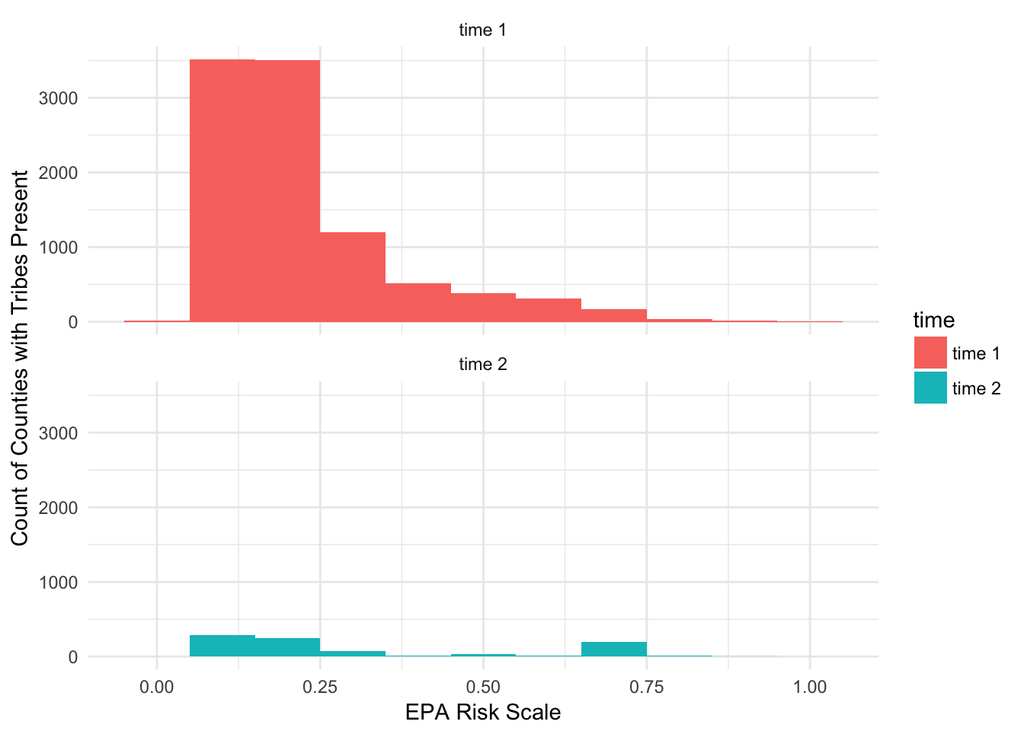

```r
ggplot(main_join1, aes(Risk, fill = time)) +
  geom_histogram(position = "dodge", binwidth = .10) +
  theme_minimal() +
  ylab("Count of Counties with Tribes Present") +
  xlab("EPA Risk Scale") +
  facet_wrap(~ time, nrow = 2)
```

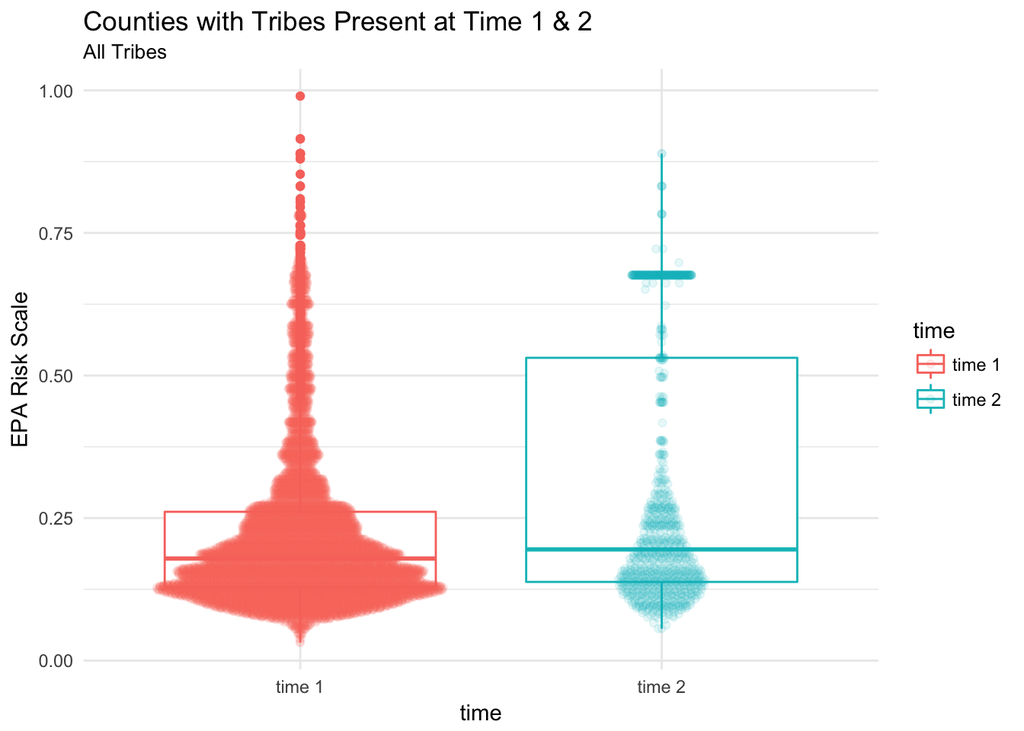

```r
ggplot(main_join1, aes(time, Risk, colour = time)) +
  geom_boxplot() +
  geom_quasirandom(alpha = 1/10, varwidth = TRUE) +
  theme_minimal() +
  ylab("EPA Risk Scale") +
  ggtitle("Counties with Tribes Present at Time 1 & 2", "All Tribes")
```

### Only tribes including both time 1 and time 2 data

- No major differences between this data and all tribes data, expect that EPA Risk at t2 seems more similar to t1 than when the two distributions include all tribes.

**Precipitation for tribes with both t1 and t2**

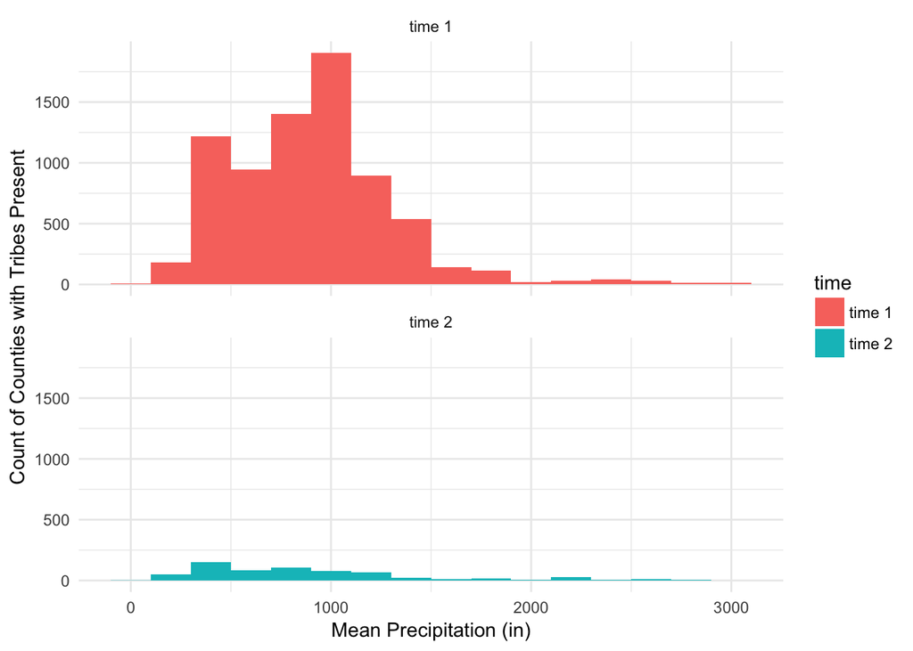

```r
ggplot(data_t1and2_long, aes(Precip, fill = time)) +
  geom_histogram(position = "dodge", binwidth = 200) +
  theme_minimal() +
  ylab("Count of Counties with Tribes Present") +
  xlab("Mean Precipitation (in)") +
  facet_wrap(~ time, nrow = 2)
```

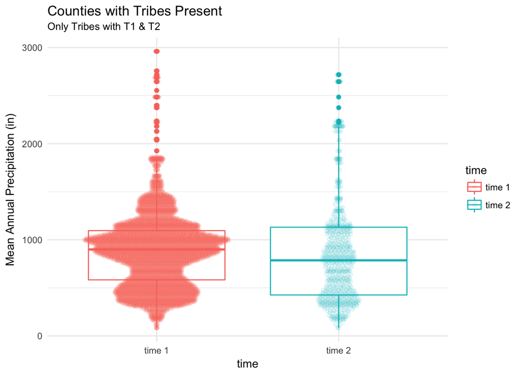

```r
ggplot(data_t1and2_long, aes(time, Precip, colour = time)) +
  geom_boxplot() +
  geom_quasirandom(alpha = 1/10, varwidth = TRUE) +
  theme_minimal() +
  ylab("Mean Annual Precipitation (in)") +
  ggtitle("Counties with Tribes Present", "Only Tribes with T1 & T2")
```

**EPA Risk for tribes with both t1 and t2**

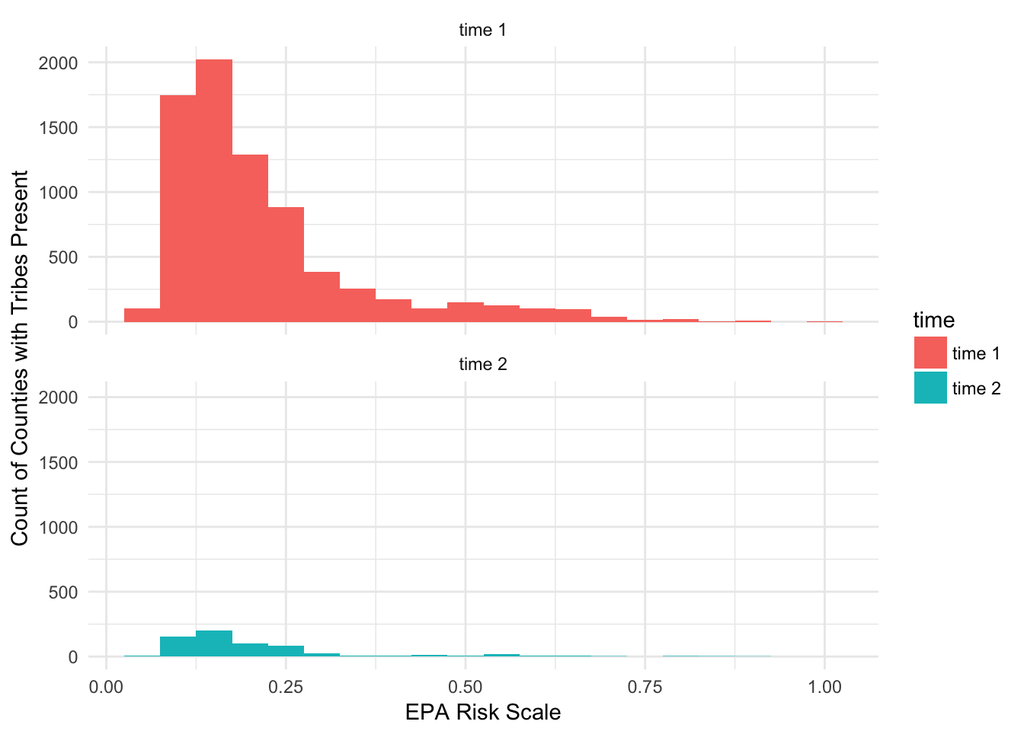

```r
ggplot(data_t1and2_long, aes(Risk, fill = time)) +
  geom_histogram(position = "dodge", binwidth = .05) +
  theme_minimal() +
  ylab("Count of Counties with Tribes Present") +
  xlab("EPA Risk Scale") +
  facet_wrap(~ time, nrow = 2)
```

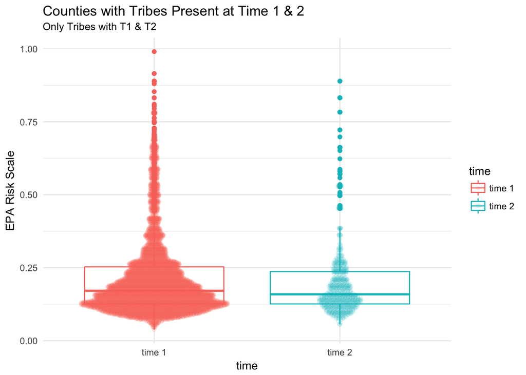

```r
ggplot(data_t1and2_long, aes(time, Risk, colour = time)) +
  geom_boxplot() +
  geom_quasirandom(alpha = 1/10, varwidth = TRUE) +
  theme_minimal() +
  ylab("EPA Risk Scale") +
  ggtitle("Counties with Tribes Present at Time 1 & 2", "Only Tribes with T1 & T2")
```

## Test for Significant Difference

### Examine whether Precipitation and EPA Risk distributions seem to be approximately normal

- None of these variables seem to be normally distributed (though Precipitation distributions come closer than EPA Risk). However, for all distributions the issue seems to be at the tails, so a transformation might help us move forward.

Make Q-Q plots for Precipitation and EPA Risk for all counties with tribes and counties with tribes that have data at both t1 and t2. Q-Q plots show the actual data (y axis) plotted against the theoretical data of a normal distribution (x axis). If the actual data are normally distributed, the points should roughly fall along a 45 degree line.

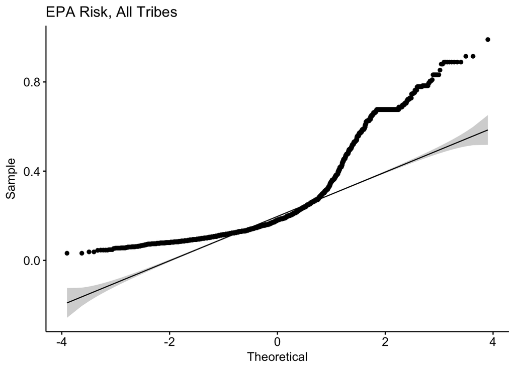

```r
# Download library used for Q-Q plot.
library(ggpubr)

# Graph Q-Q plots
ggqqplot(main_join1$Risk) + ggtitle("EPA Risk, All Tribes")
```

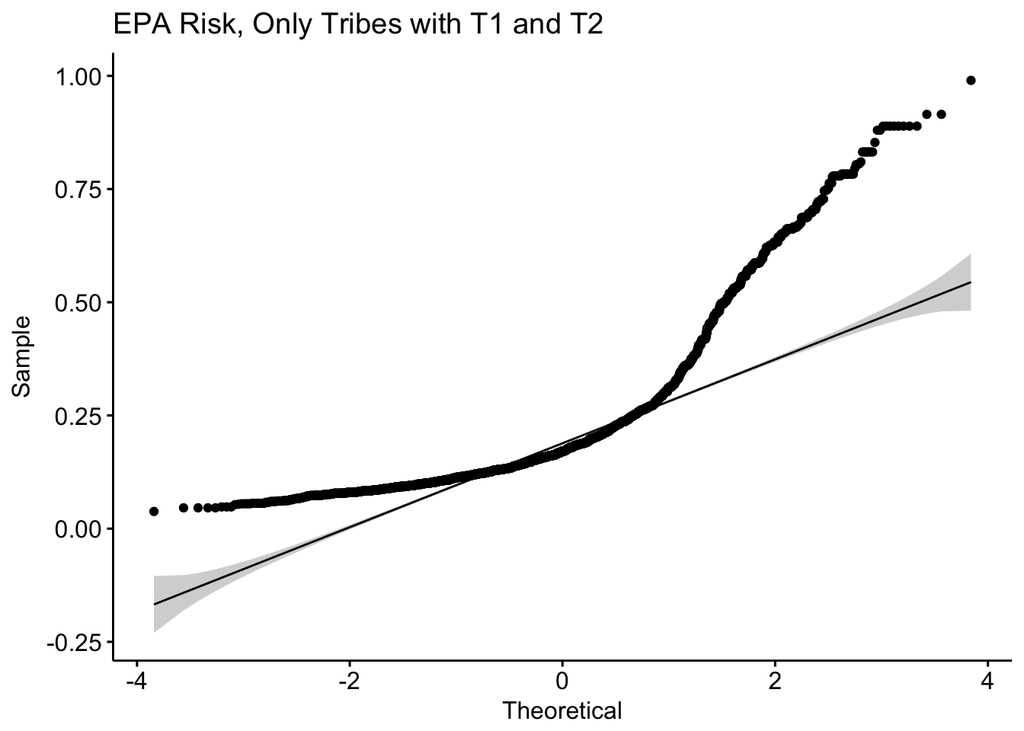

```r
ggqqplot(data_t1and2_long$Risk) + ggtitle("EPA Risk, Only Tribes with T1 and T2")
```

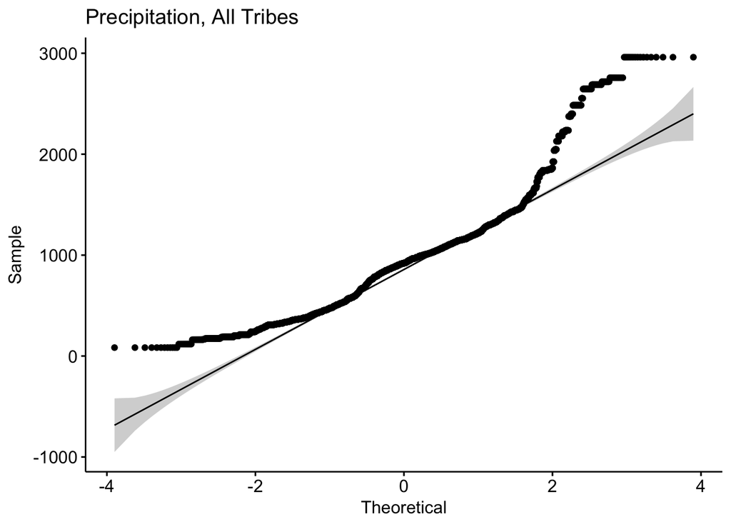

```r
ggqqplot(main_join1$Precip) + ggtitle("Precipitation, All Tribes")
```

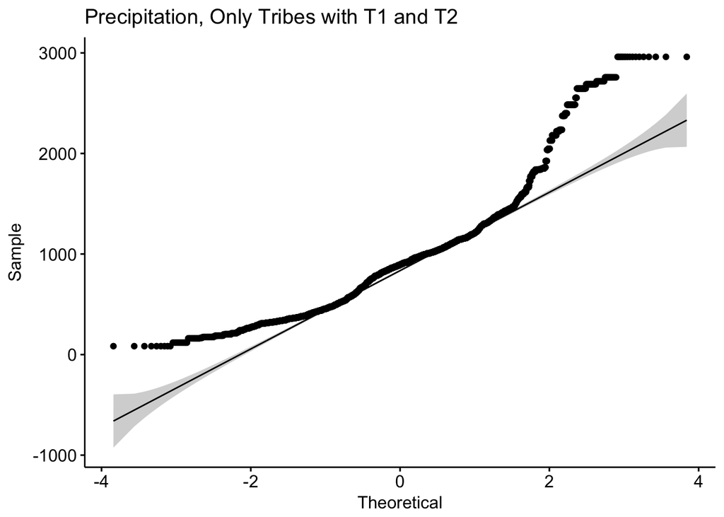

```r
ggqqplot(data_t1and2_long$Precip) + ggtitle("Precipitation, Only Tribes with T1 and T2")
```

### Run preliminary t-tests

- Here I do not use a Wilcoxon rank sum test because the variables are continuously distributed. Instead I start with simple t-tests.
- There is not a statistically significant difference between Precipitation at t1 and at t2 for either all tribes or for tribes at only t1 and t2.
- The difference in EPA Risk at t1 and t2 is statistically significant at p = .05 for all tribes but not for tribes only at t1 and t2.

```r
# T-test for all tribe-counties and precipitation
precip_all_ttest <- t.test(main_join1$Precip[main_join1$time == "time 1"],
                           main_join1$Precip[main_join1$time == "time 2"])

precip_all_ttest
```

```
##
##  Welch Two Sample t-test
##
## data:  main_join1$Precip[main_join1$time == "time 1"] and main_join1$Precip[main_join1$time == "time 2"]
## t = 0.21306, df = 739.04, p-value = 0.8313
## alternative hypothesis: true difference in means is not equal to 0
## 95 percent confidence interval:
##  -39.74648  49.42399
## sample estimates:
## mean of x mean of y
##  912.9834  908.1447
```

```r
# T-test for only t1 and t2 tribe-counties and precipitation
precip_t1t2_ttest <- t.test(data_t1and2_long$Precip[data_t1and2_long$time == "time 1"],
                           data_t1and2_long$Precip[data_t1and2_long$time == "time 2"])

precip_all_ttest
```

```
##
##  Welch Two Sample t-test
##
## data:  main_join1$Precip[main_join1$time == "time 1"] and main_join1$Precip[main_join1$time == "time 2"]
## t = 0.21306, df = 739.04, p-value = 0.8313
## alternative hypothesis: true difference in means is not equal to 0
## 95 percent confidence interval:
##  -39.74648  49.42399
## sample estimates:
## mean of x mean of y
##  912.9834  908.1447
```

```r
# T-test for all tribe-counties and EPA risk
risk_all_ttest <- t.test(main_join1$Risk[main_join1$time == "time 1"],
                           main_join1$Risk[main_join1$time == "time 2"])

risk_all_ttest
```

```
##
##  Welch Two Sample t-test
##
## data:  main_join1$Risk[main_join1$time == "time 1"] and main_join1$Risk[main_join1$time == "time 2"]
## t = -10.904, df = 946.37, p-value < 2.2e-16
## alternative hypothesis: true difference in means is not equal to 0
## 95 percent confidence interval:
##  -0.09980720 -0.06936118
## sample estimates:
## mean of x mean of y
## 0.2233932 0.3079773
```

```r
# T-test for only t1 and t2 tribe-counties and EPA risk
risk_t1t2_ttest <- t.test(data_t1and2_long$Risk[data_t1and2_long$time == "time 1"],
                            data_t1and2_long$Risk[data_t1and2_long$time == "time 2"])

risk_t1t2_ttest
```

```
##
##  Welch Two Sample t-test
##
## data:  data_t1and2_long$Risk[data_t1and2_long$time == "time 1"] and data_t1and2_long$Risk[data_t1and2_long$time == "time 2"]
## t = 1.4542, df = 753.42, p-value = 0.1463
## alternative hypothesis: true difference in means is not equal to 0
## 95 percent confidence interval:
##  -0.002894651  0.019435654
## sample estimates:
## mean of x mean of y
## 0.2158257 0.2075552
```